# Homework1_AS

Alexandra Sauk

2020-01-15

# Part 1

## Question 1

Vectors for each strain of potato.

```r
T.strain.A=c(0.17,0.20,0.13,0.20,0.24,0.25,0.15,0.21,0.21)
T.strain.B=c(0.47,0.21,0.34,0.32,0.33,0.29,0.18,0.20,0.25)
Common.strain=c(0.44,0.33,0.37,0.33,0.31,0.27,0.22,0.30,0.28)
```

## Question 2

The difference between the means of the two transgenic strains is 0.09 μmoles/g.

```r
delta.meansq2=((mean(T.strain.B))-(mean(T.strain.A)))
delta.meansq2
```

```
## [1] 0.09222222
```

## Question 3

The difference between the means of the common strain and transgenic strain A is 0.12 μmoles/g.

```r
delta.meansq3=((mean(Common.strain))-(mean(T.strain.A)))
delta.meansq3
```

```
## [1] 0.1211111
```

## Question 4

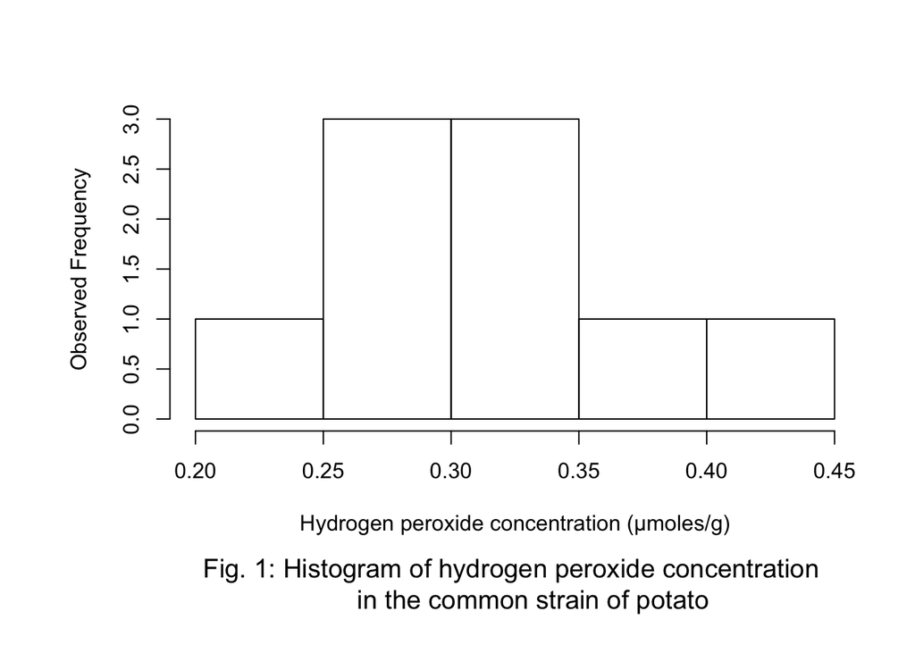

```r
par(mar=c(8.5,6.5,4.1,2.1), mgp=c(3,1,0))
hist(Common.strain, main = NULL, xlab="Hydrogen peroxide concentration (μmoles/g)", ylab = "Observed Frequency")
title(sub = "Fig. 1: Histogram of hydrogen peroxide concentration
     in the common strain of potato", line=6, cex.sub=1.2)
```

## Question 5

```r
Peroxide=c(0.27,0.21,0.34,0.32,0.24,0.29,0.18,0.20,0.29)
Growth.rate=c(1.79,1.01,1.71,1.89,1.41,1.15,1.13,1.20,1.10)

mydata=data.frame('Peroxide'=Peroxide, 'Growth.rate'=Growth.rate)
mydata
```

```
##   Peroxide Growth.rate
## 1     0.27        1.79
## 2     0.21        1.01
## 3     0.34        1.71
## 4     0.32        1.89
## 5     0.24        1.41
## 6     0.29        1.15
## 7     0.18        1.13
## 8     0.20        1.20
## 9     0.29        1.10
```

## Question 6

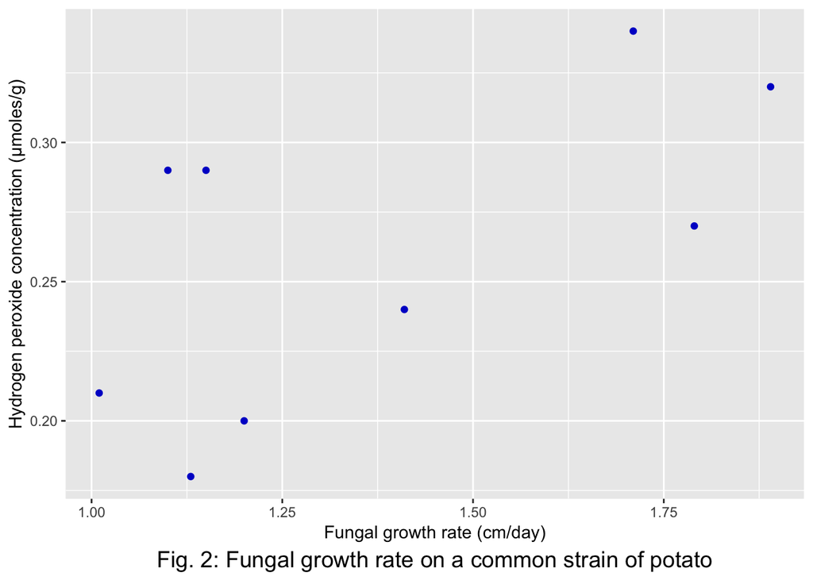

```r
library("ggplot2")
par(mar=c(5.5,6.5,4.1,2.1))
ggplot(mydata, aes(mydata$Growth.rate, mydata$Peroxide)) + geom_point(col="medium blue") + labs(y="Hydrogen peroxide concentration (μmoles/g)", x="Fungal growth rate (cm/day)", title = NULL, caption = "Fig. 2: Fungal growth rate on a common strain of potato") + theme(plot.caption = element_text(hjust = 0.5, size = 14))
```

## Question 7

The growth rate of the fungus appears to increase with increasing hydrogen peroxide concentration in the leaves of the potato plant. Thus, these results do not support the null hypothesis that hydrogen peroxide inhibits fungal growth. Although, the hypothesis is not supported, there are two replicates that show low fungal growth at high hydrogen peroxide concentrations and more replicates are needed to either rule out these data points as outliers if the trend holds, or to re-evaluate the evidence in regards to the hypothesis.

# Part 2

## Question 8

```r
turtle.data=read.csv("Homework1_turtles_AS.csv")
turtle.data
```

```
##    Nesting.status      Species
## 1         Success Olive Ridley
## 2         Success Olive Ridley
## 3         Success Olive Ridley
## 4         Success Olive Ridley
## 5         Success Olive Ridley
## 6         Success Olive Ridley
## 7         Success Olive Ridley
## 8         Success Olive Ridley
## 9         Success Olive Ridley
## 10        Success Olive Ridley
## 11        Success Olive Ridley
## 12        Success Olive Ridley
## 13        Success Olive Ridley
## 14        Success Olive Ridley
```

[output cut: 19 more lines]

## Question 9

```r
turtle.table=table(turtle.data$Nesting.status,turtle.data$Species)
turtle.table
```

```
##
##           Hawksbill Leatherback Olive Ridley
##   Aborted         3           2            4
##   Success         4           4           16
```

## Question 10

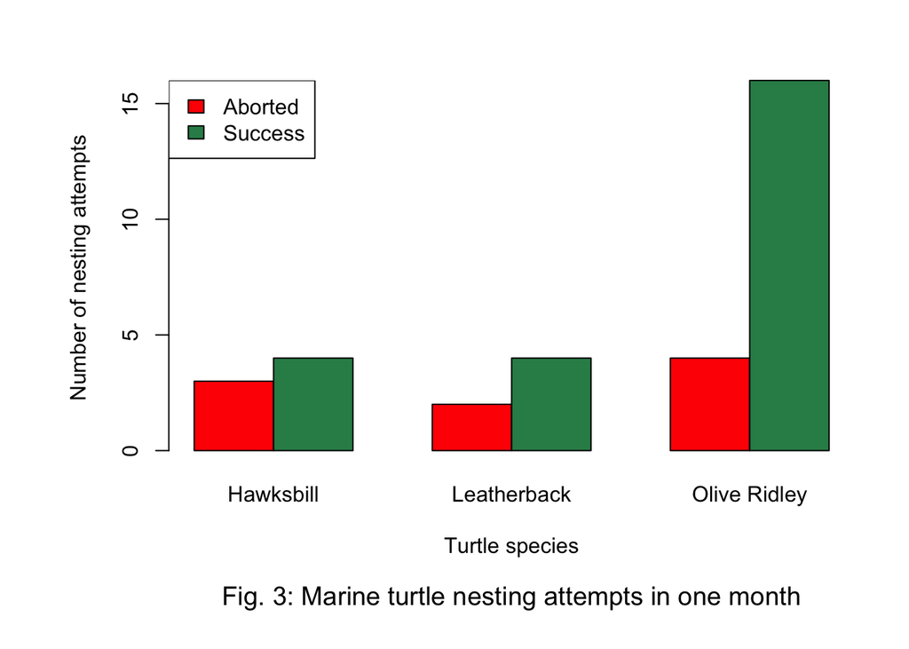

```r
par(mar=c(7.5,6.5,3.1,2.1))
turtle.plot=barplot(turtle.table, beside = TRUE, xlab = "Turtle species", ylab = "Number of nesting attempts", col = c("red","sea green"))
legend("topleft", legend=c("Aborted", "Success"), fill = c("red","sea green"))
title(sub="Fig. 3: Marine turtle nesting attempts in one month", cex.sub=1.2, line=5)
```

## Question 11

The mean number of successful nesting attempts by all marine turtles was 8 turtles and the standard deviation is 6.9.

```r
Successful=c(4,4,16)
Aborted=c(3,2,4)
mean=mean(Successful)
sd=sd(Successful)
mean
```

```
## [1] 8
```

```r
sd
```

```
## [1] 6.928203
```

## Question 12

The proportion of failed nesting attempts is 0.43 for Hawksbills, 0.33 for Leatherbacks, and 0.20 for Olive Ridleys. Based on these results Hawksbills are in need for the greatest conservation effort to ensure successful nesting.*

*While ensuring successful nesting and that hatchling turtles make it to the water safely is important conservation practice, protections for breeding age individuals have been more effective in growing marine turtle population sizes.

```r
proportion.aborted=Aborted/(Aborted+Successful)
proportion.aborted
```

```
## [1] 0.4285714 0.3333333 0.2000000
```

```r
Species=c("Hawksbill", "Leatherback", "Olive Ridley")
data.frame(Species, proportion.aborted)
```

```
##        Species proportion.aborted
## 1    Hawksbill          0.4285714
## 2  Leatherback          0.3333333
## 3 Olive Ridley          0.2000000
```

# Question 13

```r
egg.data=read.csv("Homework1_turtle_eggs_AS.csv")
egg.data
```

```
##    Nest Olive.Ridley Hawksbill Leatherback
## 1     1          127       143         149
## 2     2          110       144         143
## 3     3          112       124         128
## 4     4          110       145         111
## 5     5          118       122         110
## 6     6          115       132         109
## 7     7          120       121         110
## 8     8          108       127         105
## 9     9          120       151          89
## 10   10          126       105          98
## 11   11          114       141         112
## 12   12          130       132         108
## 13   13          123       145         109
## 14   14          128       132         101
## 15   15          121       151          97
## 16   16          109       111         110
```

# Question 14

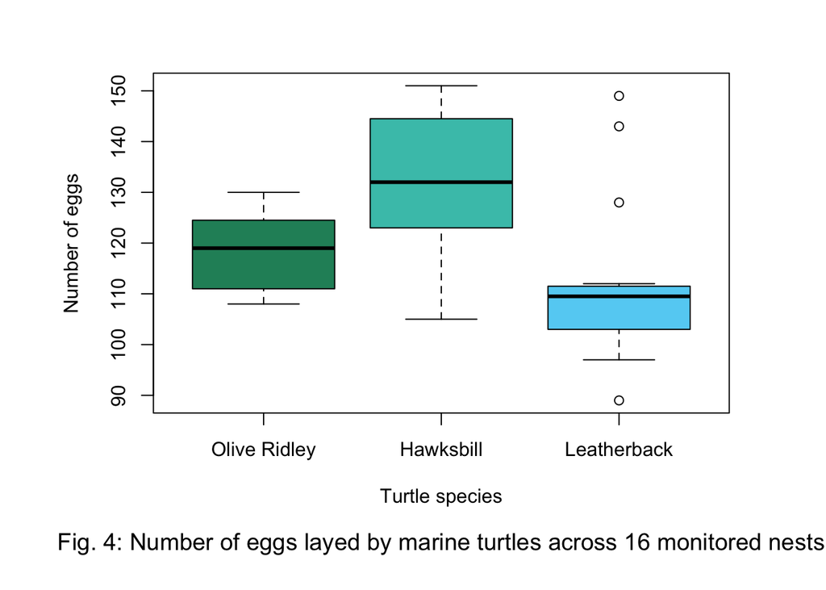

```r
par(mar=c(7.5,6.5,3.1,4.1))
boxplot(egg.data$Olive.Ridley, egg.data$Hawksbill, egg.data$Leatherback, names = c("Olive Ridley","Hawksbill", "Leatherback"), xlab = "Turtle species", ylab = "Number of eggs", col=c("#238E68","#45C3B8","#63D1F4"))
title(sub="Fig. 4: Number of eggs layed by marine turtles across 16 monitored nests", cex.sub=1.2, line=5)
```

## Question 15

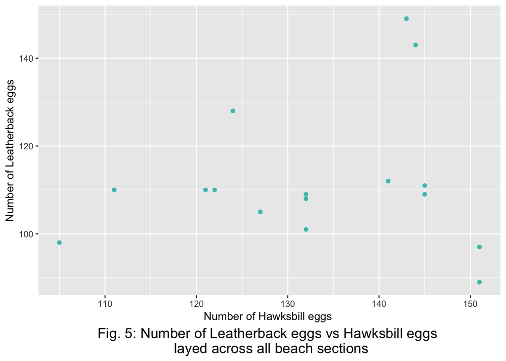

```r
par(mar=c(7.5,6.5,3.1,4.1))
ggplot(egg.data, aes(y=egg.data$Leatherback, x=egg.data$Hawksbill)) + geom_point(col=("#45C3B8")) + labs(y="Number of Leatherback eggs", x="Number of Hawksbill eggs ", title = NULL, caption = "Fig. 5: Number of Leatherback eggs vs Hawksbill eggs \n layed across all beach sections") + theme(plot.caption = element_text(hjust = 0.5, size = 14))
```